# Tugas Pertemuan 2

Gemala Aleida Fitri G1401231070

```r
library("forecast")
```

```r
library("graphics")
library("TTR")
library("TSA")
```

## Impor Data

```r
library(rio) #install packages jika belum ada
data <- import("https://raw.githubusercontent.com/fadiela/mpdw/refs/heads/main/Pertemuan%201/data/Telur%20Ayam%20Ras.csv")

data1 <- data[1:159,]

# menampilkan 5 data pertama
head(data1)
```

```
##         Date Jawa Barat
## 1 2022-07-14      27680
## 2 2022-07-15      27920
## 3 2022-07-16      27960
## 4 2022-07-17      27890
## 5 2022-07-18      27950
## 6 2022-07-19      28260
```

## Eksplorasi Data

```r
View(data1)
str(data1)
```

```
## 'data.frame':    159 obs. of  2 variables:
##  $ Date      : IDate, format: "2022-07-14" "2022-07-15" ...
##  $ Jawa Barat: int  27680 27920 27960 27890 27950 28260 28150 28100 28080 28020 ...
```

```r
dim(data1)
```

```
## [1] 159   2
```

```r
data1.ts <- ts(data1$`Jawa Barat`)
```

```r
summary(data1.ts)
```

```
##    Min. 1st Qu.  Median    Mean 3rd Qu.    Max.
##   24470   26915   27960   28188   29940   31390
```

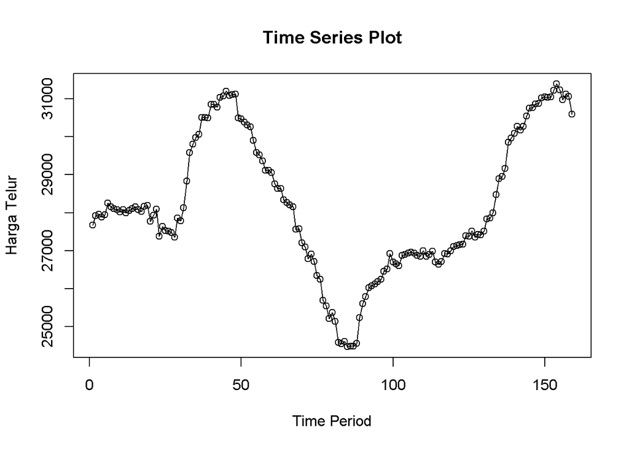

```r
ts.plot(data1.ts, xlab="Time Period", ylab="Harga Telur",
        main = "Time Series Plot")
points(data1.ts)
```

```r
#menyimpan plot
dev.copy(png, "plot_data1.png")
```

```r
dev.off()
```

## Single Exponential Smoothing & Double Exponential Smoothing

### Pembagian Data

Pembagian data latih dan data uji dilakukan dengan perbandingan 80% data latih dan 20% data uji.

```r
# jumlah baris data
n <- nrow(data1)

# hitung batas 80%
n_train <- floor(0.8 * n)

# bagi data
training <- data1[1:n_train, ]
testing  <- data1[(n_train+1):n, ]

# ubah ke time series
train.ts <- ts(training$`Jawa Barat`)
test.ts  <- ts(testing$`Jawa Barat`)
```

### Eksplorasi

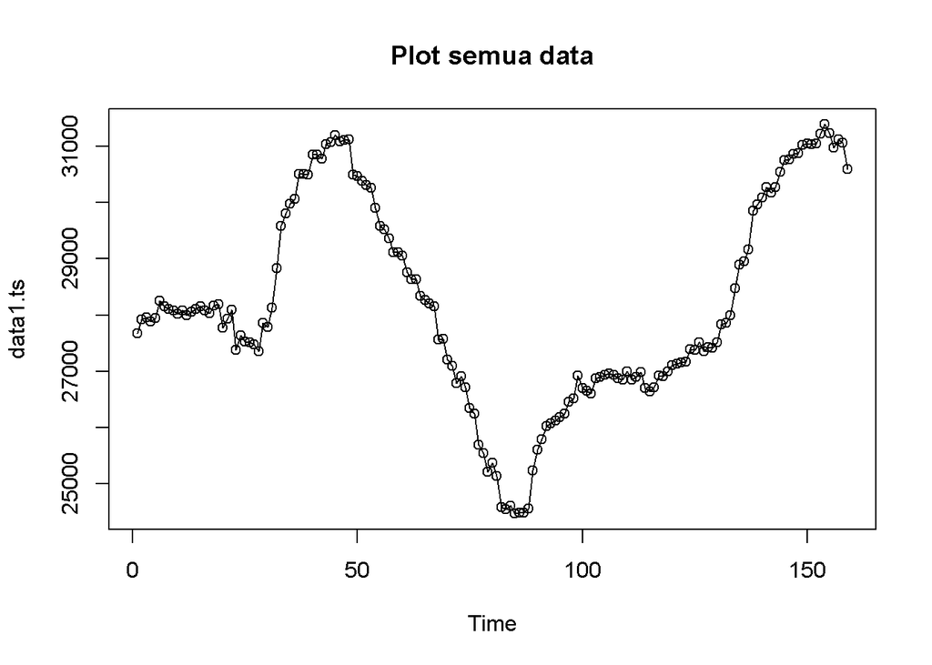

```r
#eksplorasi data
plot(data1.ts, col="black",main="Plot semua data")
points(data1.ts)
```

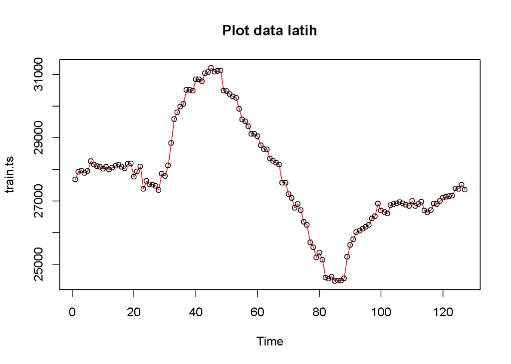

```r
plot(train.ts, col="red",main="Plot data latih")
points(train.ts)
```

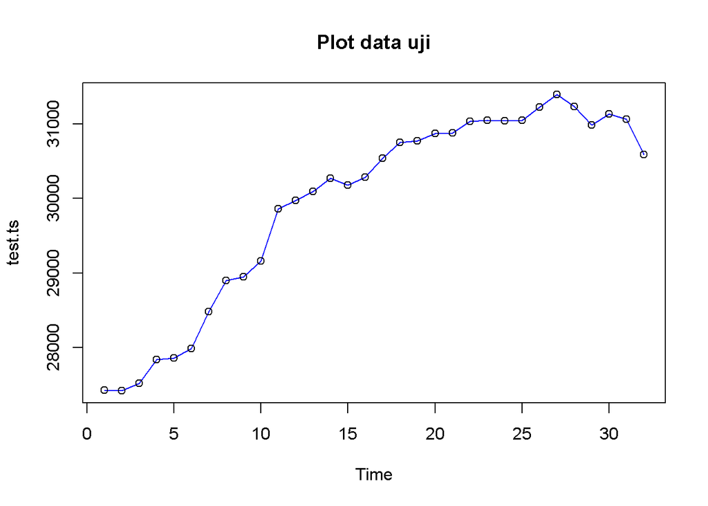

```r
plot(test.ts, col="blue",main="Plot data uji")
points(test.ts)
```

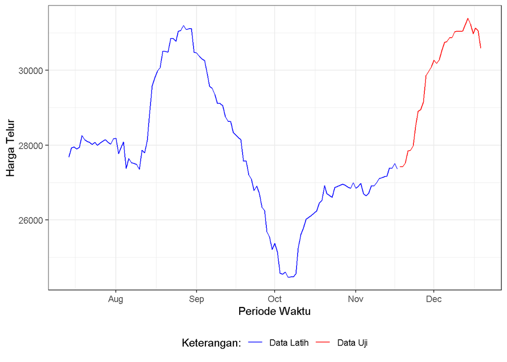

```r
#Eksplorasi dengan GGPLOT
library(ggplot2)
ggplot() +
  geom_line(data = training, aes(x = Date, y = `Jawa Barat`, col = "Data Latih")) +
  geom_line(data = testing, aes(x = Date,  y = `Jawa Barat`, col = "Data Uji")) +
  labs(x = "Periode Waktu", y = "Harga Telur", color = "Legend") +
  scale_colour_manual(name="Keterangan:", breaks = c("Data Latih", "Data Uji"),
                      values = c("blue", "red")) +
  theme_bw() + theme(legend.position = "bottom",
                     plot.caption = element_text(hjust=0.5, size=12))
```

## Single Exponential Smoothing

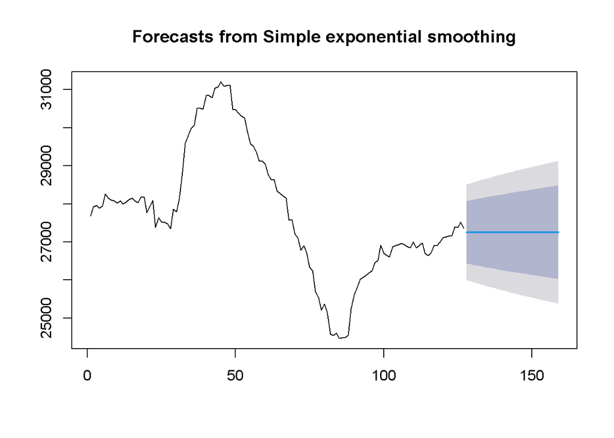

```r
#Cara 1 (fungsi ses)
ses.1 <- ses(train.ts, h = 32, alpha = 0.2)
plot(ses.1)
```

```r
ses.1
```

```
##     Point Forecast    Lo 80    Hi 80    Lo 95    Hi 95
## 128       27255.34 26437.82 28072.86 26005.05 28505.63
## 129       27255.34 26421.63 28089.05 25980.29 28530.39
## 130       27255.34 26405.74 28104.93 25956.00 28554.68
## 131       27255.34 26390.15 28120.52 25932.15 28578.52
## 132       27255.34 26374.84 28135.83 25908.73 28601.94
## 133       27255.34 26359.79 28150.89 25885.71 28624.96
## 134       27255.34 26344.98 28165.69 25863.07 28647.60
## 135       27255.34 26330.42 28180.26 25840.80 28669.88
## 136       27255.34 26316.08 28194.60 25818.86 28691.81
## 137       27255.34 26301.95 28208.72 25797.26 28713.41
## 138       27255.34 26288.03 28222.64 25775.97 28734.70
## 139       27255.34 26274.31 28236.36 25754.99 28755.68
## 140       27255.34 26260.78 28249.89 25734.29 28776.38
## 141       27255.34 26247.43 28263.24 25713.88 28796.80
```

[output cut: 18 more lines]

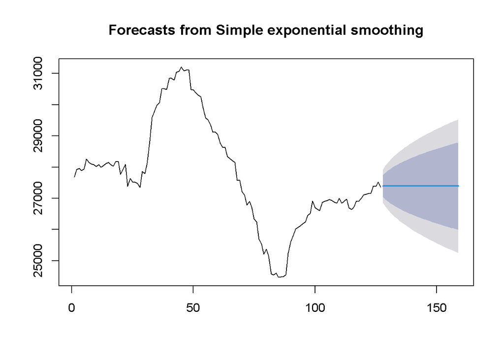

```r
ses.2<- ses(train.ts, h = 32, alpha = 0.7)
plot(ses.2)
```

```r
ses.2
```

```
##     Point Forecast    Lo 80    Hi 80    Lo 95    Hi 95
## 128       27391.73 27044.30 27739.16 26860.38 27923.07
## 129       27391.73 26967.64 27815.82 26743.14 28040.32
## 130       27391.73 26902.86 27880.60 26644.06 28139.39
## 131       27391.73 26845.70 27937.75 26556.66 28226.80
## 132       27391.73 26793.99 27989.46 26477.57 28305.89
## 133       27391.73 26746.41 28037.04 26404.80 28378.66
## 134       27391.73 26702.11 28081.35 26337.04 28446.42
## 135       27391.73 26660.48 28122.98 26273.38 28510.08
## 136       27391.73 26621.10 28162.36 26213.15 28570.31
## 137       27391.73 26583.63 28199.82 26155.85 28627.60
## 138       27391.73 26547.83 28235.63 26101.10 28682.36
## 139       27391.73 26513.49 28269.97 26048.57 28734.88
## 140       27391.73 26480.44 28303.02 25998.03 28785.43
## 141       27391.73 26448.54 28334.91 25949.25 28834.21
```

[output cut: 18 more lines]

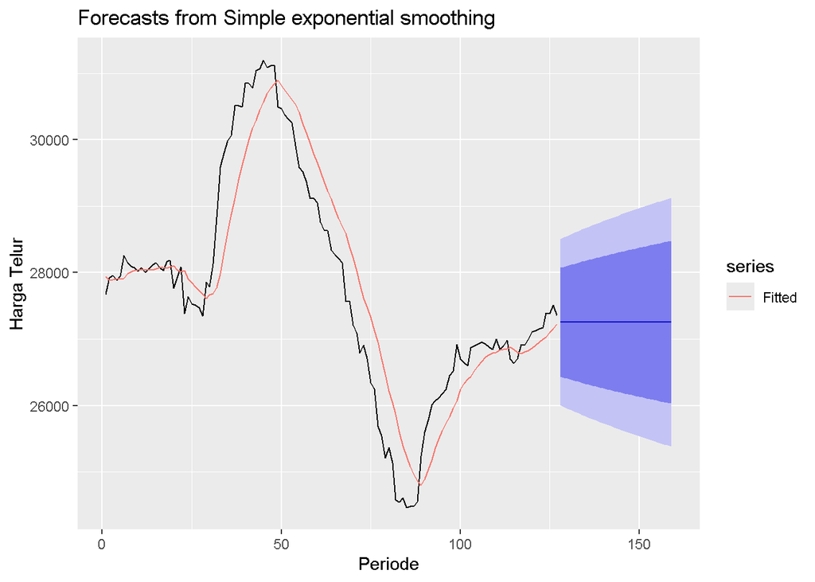

```r
autoplot(ses.1) +
  autolayer(fitted(ses.1), series="Fitted") +
  ylab("Harga Telur") + xlab("Periode")
```

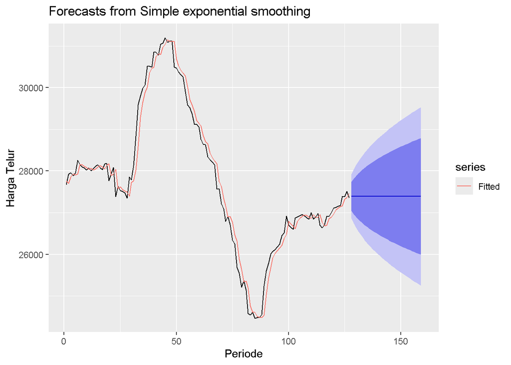

```r
autoplot(ses.2) +
  autolayer(fitted(ses.2), series="Fitted") +
  ylab("Harga Telur") + xlab("Periode")
```

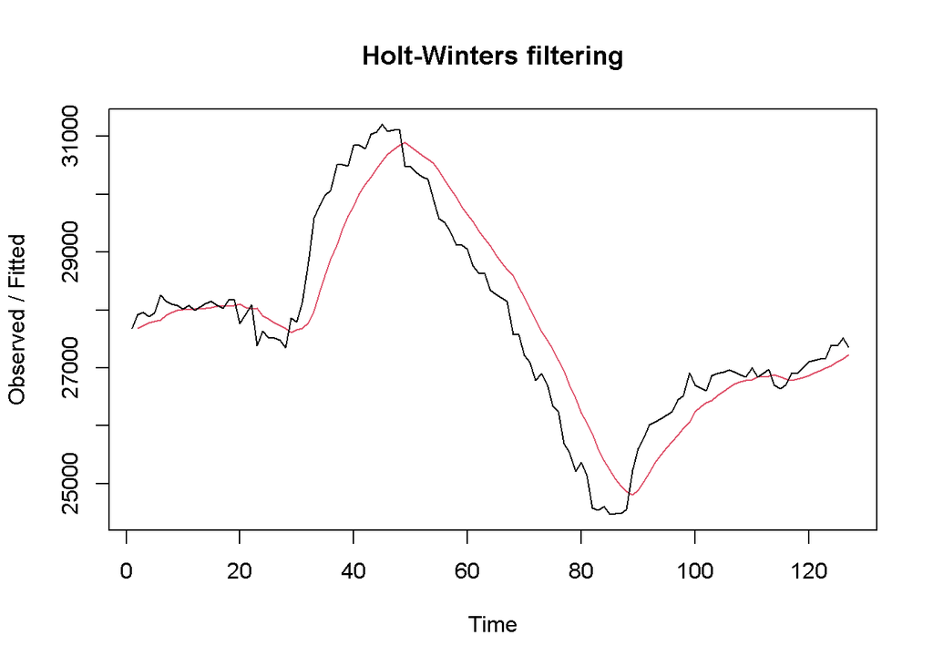

```r
#Cara 2 (fungsi Holtwinter)
ses1<- HoltWinters(train.ts, gamma = FALSE, beta = FALSE, alpha = 0.2)
plot(ses1)
```

```r
#ramalan
ramalan1<- forecast(ses1, h=32)
ramalan1
```

```
##     Point Forecast    Lo 80    Hi 80    Lo 95    Hi 95
## 128       27255.34 26436.59 28074.09 26003.17 28507.50
## 129       27255.34 26420.37 28090.30 25978.37 28532.30
## 130       27255.34 26404.47 28106.21 25954.05 28556.63
## 131       27255.34 26388.85 28121.82 25930.17 28580.51
## 132       27255.34 26373.52 28137.16 25906.71 28603.96
## 133       27255.34 26358.44 28152.23 25883.66 28627.02
## 134       27255.34 26343.62 28167.06 25860.98 28649.69
## 135       27255.34 26329.03 28181.64 25838.67 28672.00
## 136       27255.34 26314.67 28196.01 25816.71 28693.97
## 137       27255.34 26300.52 28210.15 25795.07 28715.60
## 138       27255.34 26286.58 28224.09 25773.75 28736.92
## 139       27255.34 26272.84 28237.83 25752.74 28757.94
## 140       27255.34 26259.29 28251.39 25732.01 28778.66
## 141       27255.34 26245.92 28264.76 25711.56 28799.11
```

[output cut: 18 more lines]

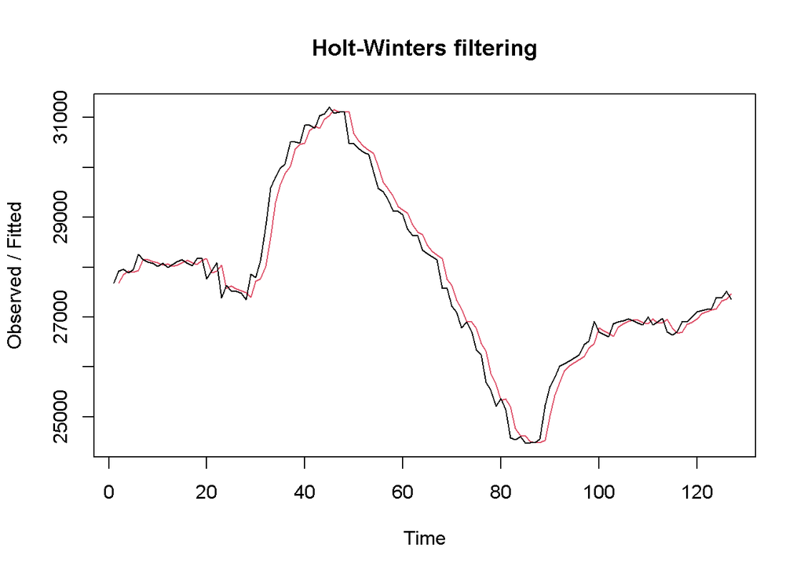

```r
ses2<- HoltWinters(train.ts, gamma = FALSE, beta = FALSE, alpha = 0.7)
plot(ses2)
```

```r
#ramalan
ramalan2<- forecast(ses2, h=32)
ramalan2
```

```
##     Point Forecast    Lo 80    Hi 80    Lo 95    Hi 95
## 128       27391.73 27044.21 27739.25 26860.25 27923.21
## 129       27391.73 26967.53 27815.93 26742.97 28040.49
## 130       27391.73 26902.73 27880.73 26643.87 28139.59
## 131       27391.73 26845.56 27937.90 26556.44 28227.02
## 132       27391.73 26793.84 27989.62 26477.33 28306.13
## 133       27391.73 26746.24 28037.21 26404.54 28378.91
## 134       27391.73 26701.92 28081.53 26336.77 28446.69
## 135       27391.73 26660.29 28123.17 26273.09 28510.37
## 136       27391.73 26620.90 28162.56 26212.84 28570.61
## 137       27391.73 26583.42 28200.03 26155.53 28627.93
## 138       27391.73 26547.61 28235.85 26100.76 28682.70
## 139       27391.73 26513.26 28270.20 26048.22 28735.23
## 140       27391.73 26480.20 28303.26 25997.66 28785.79
## 141       27391.73 26448.30 28335.16 25948.87 28834.58
```

[output cut: 18 more lines]

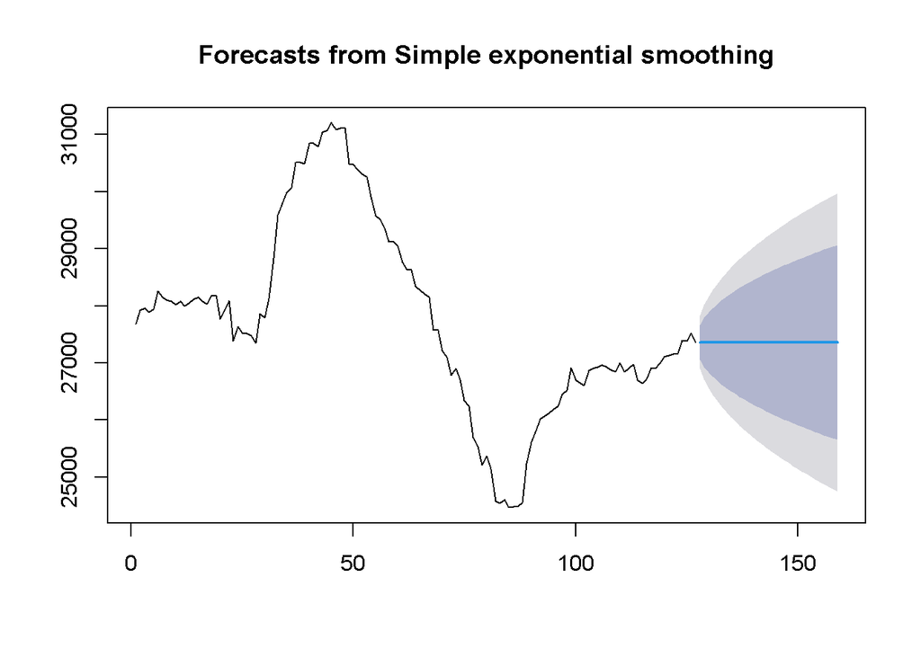

```r
#SES
ses.opt <- ses(train.ts, h = 32, alpha = NULL)
plot(ses.opt)
```

```r
ses.opt
```

```
##     Point Forecast    Lo 80    Hi 80    Lo 95    Hi 95
## 128       27360.02 27058.35 27661.68 26898.66 27821.37
## 129       27360.02 26933.42 27786.61 26707.60 28012.43
## 130       27360.02 26837.56 27882.47 26560.98 28159.05
## 131       27360.02 26756.74 27963.29 26437.38 28282.65
## 132       27360.02 26685.53 28034.50 26328.49 28391.54
## 133       27360.02 26621.16 28098.87 26230.03 28490.00
## 134       27360.02 26561.96 28158.07 26139.50 28580.53
## 135       27360.02 26506.86 28213.17 26055.23 28664.80
## 136       27360.02 26455.11 28264.92 25976.09 28743.94
## 137       27360.02 26406.16 28313.87 25901.23 28818.80
## 138       27360.02 26359.61 28360.42 25830.03 28890.00
## 139       27360.02 26315.13 28404.90 25761.99 28958.04
## 140       27360.02 26272.46 28447.57 25696.74 29023.29
## 141       27360.02 26231.41 28488.62 25633.96 29086.07
```

[output cut: 18 more lines]

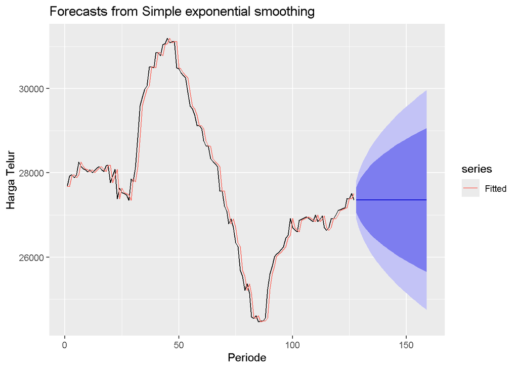

```r
autoplot(ses.opt) +
  autolayer(fitted(ses.opt), series="Fitted") +
  ylab("Harga Telur") + xlab("Periode")
```

```r
#Lamda Optimum Holt Winter
HWopt<- HoltWinters(train.ts, gamma = FALSE, beta = FALSE,alpha = NULL)
HWopt
```

```
## Holt-Winters exponential smoothing without trend and without seasonal component.
##
## Call:
## HoltWinters(x = train.ts, alpha = NULL, beta = FALSE, gamma = FALSE)
##
## Smoothing parameters:
##  alpha: 0.9999502
##  beta : FALSE
##  gamma: FALSE
##
## Coefficients:
##       [,1]
## a 27360.01
```

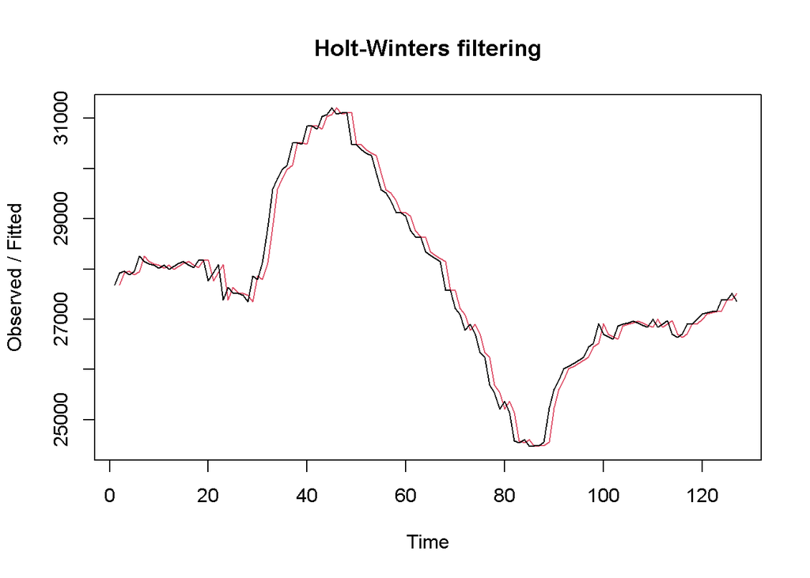

```r
plot(HWopt)
```

```r
#ramalan
ramalanopt<- forecast(HWopt, h=32)
ramalanopt
```

```
##     Point Forecast    Lo 80    Hi 80    Lo 95    Hi 95
## 128       27360.01 27058.37 27661.65 26898.69 27821.33
## 129       27360.01 26933.43 27786.58 26707.62 28012.39
## 130       27360.01 26837.57 27882.45 26561.01 28159.01
## 131       27360.01 26756.75 27963.27 26437.40 28282.61
## 132       27360.01 26685.55 28034.47 26328.51 28391.51
## 133       27360.01 26621.17 28098.84 26230.06 28489.96
## 134       27360.01 26561.98 28158.04 26139.52 28580.49
## 135       27360.01 26506.88 28213.14 26055.26 28664.76
## 136       27360.01 26455.13 28264.89 25976.11 28743.90
## 137       27360.01 26406.18 28313.83 25901.25 28818.76
## 138       27360.01 26359.63 28360.39 25830.06 28889.96
## 139       27360.01 26315.14 28404.87 25762.03 28957.99
## 140       27360.01 26272.48 28447.54 25696.78 29023.24
## 141       27360.01 26231.43 28488.59 25633.99 29086.02
```

[output cut: 18 more lines]

#### Akurasi Data Latih

Perhitungan akurasi data dapat dilakukan dengan cara langsung maupun manual. Secara langsung, nilai akurasi dapat diambil dari objek yang tersimpan pada hasil SES, yaitu *sum of squared errors* (SSE). Nilai akurasi lain dapat dihitung pula dari nilai SSE tersebut.

```r
#Keakuratan Metode
#Pada data training

# SES dengan alpha = 0.2
SSE1<-ses1$SSE
MSE1<-ses1$SSE/length(train.ts)
RMSE1<-sqrt(MSE1)

akurasi1 <- matrix(c(SSE1,MSE1,RMSE1))
row.names(akurasi1)<- c("SSE", "MSE", "RMSE")
colnames(akurasi1) <- c("Akurasi lamda=0.2")
akurasi1
```

```
##      Akurasi lamda=0.2
## SSE       5.105559e+07
## MSE       4.020125e+05
## RMSE      6.340446e+02
```

```r
# SES dengan alpha = 0.7
SSE2<-ses2$SSE
MSE2<-ses2$SSE/length(train.ts)
RMSE2<-sqrt(MSE2)

akurasi2 <- matrix(c(SSE2,MSE2,RMSE2))
row.names(akurasi2)<- c("SSE", "MSE", "RMSE")
colnames(akurasi2) <- c("Akurasi lamda=0.7")
akurasi2
```

```
##      Akurasi lamda=0.7
## SSE       9192967.6862
## MSE         72385.5723
## RMSE          269.0457
```

```r
#Cara Manual
# Alpha = 0.2
fitted1<-ramalan1$fitted
sisaan1<-ramalan1$residuals
head(sisaan1)
```

```
## Time Series:
## Start = 1
## End = 6
## Frequency = 1
## [1]      NA 240.000 232.000 115.600 152.480 431.984
```

```r
resid1<-training$`Jawa Barat`-ramalan1$fitted
head(resid1)
```

```
## Time Series:
## Start = 1
## End = 6
## Frequency = 1
## [1]      NA 240.000 232.000 115.600 152.480 431.984
```

```r
SSE.1=sum(sisaan1[2:length(train.ts)]^2)
SSE.1
```

```
## [1] 51055590
```

```r
MSE.1 = SSE.1/length(train.ts)
MSE.1
```

```
## [1] 402012.5
```

```r
MAPE.1 = sum(abs(sisaan1[2:length(train.ts)]/train.ts[2:length(train.ts)])*
               100)/length(train.ts)
MAPE.1
```

```
## [1] 1.846948
```

```r
akurasi.1 <- matrix(c(SSE.1,MSE.1,MAPE.1))
row.names(akurasi.1)<- c("SSE", "MSE", "MAPE")
colnames(akurasi.1) <- c("Akurasi lamda=0.2")
akurasi.1
```

```
##      Akurasi lamda=0.2
## SSE       5.105559e+07
## MSE       4.020125e+05
## MAPE      1.846948e+00
```

```r
# Alpha = 0.7
fitted2<-ramalan2$fitted
sisaan2<-ramalan2$residuals
head(sisaan2)
```

```
## Time Series:
## Start = 1
## End = 6
## Frequency = 1
## [1]      NA 240.000 112.000 -36.400  49.080 324.724
```

```r
resid2<-training$`Jawa Barat`-ramalan2$fitted
head(resid2)
```

```
## Time Series:
## Start = 1
## End = 6
## Frequency = 1
## [1]      NA 240.000 112.000 -36.400  49.080 324.724
```

```r
SSE.2=sum(sisaan2[2:length(train.ts)]^2)
SSE.2
```

```
## [1] 9192968
```

```r
MSE.2 = SSE.2/length(train.ts)
MSE.2
```

```
## [1] 72385.57
```

```r
MAPE.2 = sum(abs(sisaan2[2:length(train.ts)]/train.ts[2:length(train.ts)])*
               100)/length(train.ts)
MAPE.2
```

```
## [1] 0.6917855
```

```r
akurasi.2 <- matrix(c(SSE.2,MSE.2,MAPE.2))
row.names(akurasi.2)<- c("SSE", "MSE", "MAPE")
colnames(akurasi.2) <- c("Akurasi lamda=0.7")
akurasi.2
```

```
##      Akurasi lamda=0.7
## SSE       9.192968e+06
## MSE       7.238557e+04
## MAPE      6.917855e-01
```

Berdasarkan nilai SSE, MSE, RMSE, dan MAPE di antara kedua parameter pada data latih, nilai parameter $\lambda=0,7$ menghasilkan akurasi yang lebih baik dibanding $\lambda=0,2$ . Hal ini dilihat dari nilai masing-masing ukuran akurasi yang lebih kecil. Berdasarkan nilai MAPE-nya, kedua parameter menghasilkan akurasi yang sangat baik.

#### Akurasi Data Uji

```r
# jumlah observasi uji
n_test <- nrow(testing)

# error (ramalan - aktual), samakan panjang dan tipe numeric
e1   <- as.numeric(ramalan1$mean)[1:n_test] - as.numeric(testing$`Jawa Barat`)
e2   <- as.numeric(ramalan2$mean)[1:n_test] - as.numeric(testing$`Jawa Barat`)
eopt <- as.numeric(ramalanopt$mean)[1:n_test] - as.numeric(testing$`Jawa Barat`)

# SSE / MSE / RMSE untuk masing-masing model (abaikan NA)
SSEtesting1  <- sum(e1^2,  na.rm = TRUE)
MSEtesting1  <- mean(e1^2, na.rm = TRUE)
RMSEtesting1 <- sqrt(MSEtesting1)

SSEtesting2  <- sum(e2^2,  na.rm = TRUE)
MSEtesting2  <- mean(e2^2, na.rm = TRUE)
RMSEtesting2 <- sqrt(MSEtesting2)

SSEtestingopt  <- sum(eopt^2,  na.rm = TRUE)
MSEtestingopt  <- mean(eopt^2, na.rm = TRUE)
RMSEtestingopt <- sqrt(MSEtestingopt)

# Tabel ringkas
akurasitesting_SSE <- matrix(c(SSEtesting1, SSEtesting2, SSEtestingopt),
                             nrow = 3,
                             dimnames = list(c("SSE1","SSE2","SSEopt"), "Nilai"))
akurasitesting_MSE <- matrix(c(MSEtesting1, MSEtesting2, MSEtestingopt),
                             nrow = 3,
                             dimnames = list(c("MSE1","MSE2","MSEopt"), "Nilai"))
akurasitesting_RMSE <- matrix(c(RMSEtesting1, RMSEtesting2, RMSEtestingopt),
                              nrow = 3,
                              dimnames = list(c("RMSE1","RMSE2","RMSEopt"), "Nilai"))

akurasitesting_SSE
```

```
##            Nilai
## SSE1   283081322
## SSE2   260323900
## SSEopt 265510372
```

```r
akurasitesting_MSE
```

```
##          Nilai
## MSE1   8846291
## MSE2   8135122
## MSEopt 8297199
```

```r
akurasitesting_RMSE
```

```
##            Nilai
## RMSE1   2974.272
## RMSE2   2852.214
## RMSEopt 2880.486
```

```r
accuracy(ramalan1, testing$`Jawa Barat`)
```

```
##                      ME      RMSE       MAE        MPE     MAPE      MASE
## Training set  -16.85171  636.5557  515.1573 -0.1088911 1.861606  3.203841
## Test set     2675.28815 2974.2716 2675.2882  8.7599548 8.759955 16.638021
##                   ACF1
## Training set 0.9399157
## Test set            NA
```

```r
accuracy(ramalan2, testing$`Jawa Barat`)
```

```
##                       ME      RMSE       MAE         MPE      MAPE      MASE
## Training set   -3.268388  270.1112  192.8691 -0.01809698 0.6972759  1.199482
## Test set     2538.896861 2852.2135 2538.8969  8.30337090 8.3033709 15.789783
##                   ACF1
## Training set 0.5607735
## Test set            NA
```

```r
accuracy(ramalanopt, testing$`Jawa Barat`)
```

```
##                      ME      RMSE       MAE         MPE      MAPE      MASE
## Training set   -2.53975  234.4489  160.7964 -0.01284421 0.5825855  1.000017
## Test set     2570.61754 2880.4859 2570.6175  8.40955913 8.4095591 15.987059
##                   ACF1
## Training set 0.2230474
## Test set            NA
```

Berdasarkan nilai nilai SSE, MSE, RMSE, dan MAPE pada data latih, parameter optimum ($\lambda=0,99$) menghasilkan akurasi yang lebih baik dibanding $\lambda=0,2$ dan $\lambda=0,7$. Tetapi pada data uji, parameter $\lambda=0,7$ menghasilkan akurasi yang lebih baik dibanding $\lambda=0,2$ dan parameter optimum ($\lambda=0,99$) . Hal ini dilihat dari nilai masing-masing ukuran akurasi yang lebih kecil. Jadi, dalam hal ini $\lambda=0,7$ merupakan parameter terbaik karena memberikan akurasi tertinggi pada data uji.

## *Double Exponential Smoothing* (DES)

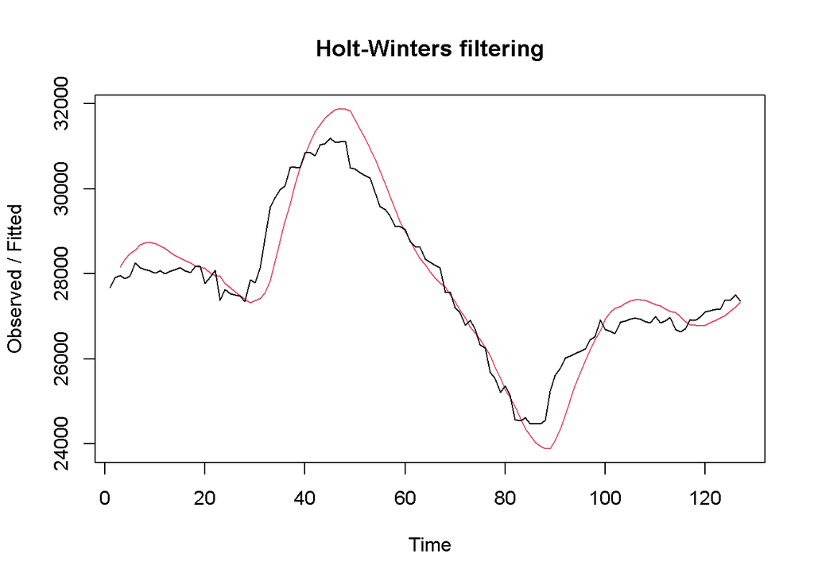

```r
#Lamda=0.2 dan gamma=0.2
des.1<- HoltWinters(train.ts, gamma = FALSE, beta = 0.2, alpha = 0.2)
plot(des.1)
```

```r
#ramalan
ramalandes1<- forecast(des.1, h=32)
ramalandes1
```

```
##     Point Forecast    Lo 80    Hi 80    Lo 95    Hi 95
## 128       27392.22 26658.24 28126.20 26269.70 28514.74
## 129       27446.82 26692.00 28201.64 26292.42 28601.21
## 130       27501.41 26719.12 28283.71 26304.99 28697.83
## 131       27556.01 26739.21 28372.80 26306.83 28805.19
## 132       27610.60 26752.13 28469.08 26297.69 28923.52
## 133       27665.20 26757.91 28572.49 26277.63 29052.77
## 134       27719.80 26756.75 28682.85 26246.94 29192.65
## 135       27774.39 26748.92 28799.86 26206.07 29342.71
## 136       27828.99 26734.80 28923.18 26155.57 29502.41
## 137       27883.58 26714.74 29052.43 26095.99 29671.18
## 138       27938.18 26689.12 29187.24 26027.91 29848.45
## 139       27992.78 26658.31 29327.24 25951.89 30033.67
## 140       28047.37 26622.62 29472.12 25868.41 30226.34
## 141       28101.97 26582.37 29621.57 25777.94 30425.99
```

[output cut: 18 more lines]

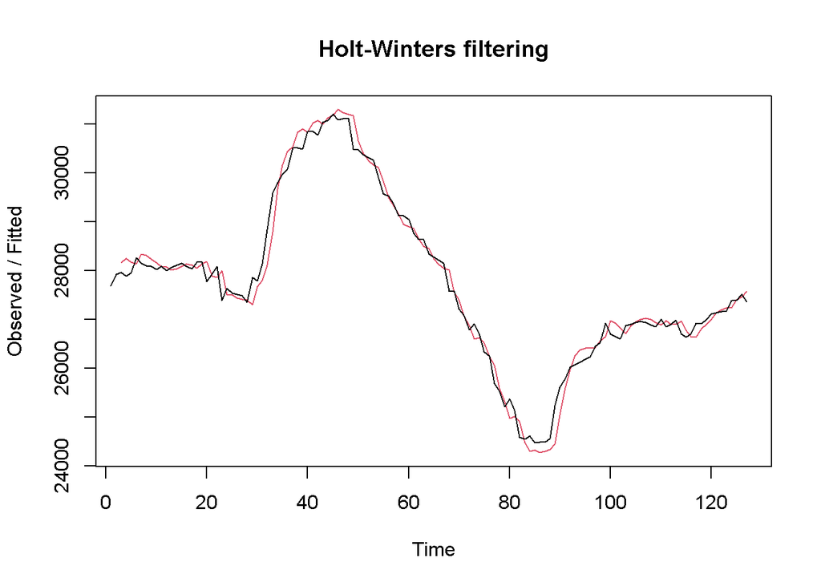

```r
#Lamda=0.6 dan gamma=0.3
des.2<- HoltWinters(train.ts, gamma = FALSE, beta = 0.3, alpha = 0.6)
plot(des.2)
```

```r
#ramalan
ramalandes2<- forecast(des.2, h=32)
ramalandes2
```

```
##     Point Forecast    Lo 80    Hi 80    Lo 95    Hi 95
## 128       27483.95 27181.71 27786.19 27021.71 27946.19
## 129       27524.87 27141.56 27908.18 26938.64 28111.09
## 130       27565.78 27085.04 28046.52 26830.55 28301.02
## 131       27606.70 27015.23 28198.16 26702.13 28511.27
## 132       27647.61 26934.17 28361.05 26556.49 28738.73
## 133       27688.53 26843.22 28533.83 26395.75 28981.31
## 134       27729.44 26743.36 28715.52 26221.35 29237.53
## 135       27770.35 26635.28 28905.43 26034.41 29506.30
## 136       27811.27 26519.54 29103.00 25835.74 29786.80
## 137       27852.18 26396.59 29307.78 25626.04 30078.33
## 138       27893.10 26266.77 29519.43 25405.85 30380.35
## 139       27934.01 26130.41 29737.62 25175.63 30692.39
## 140       27974.93 25987.75 29962.10 24935.81 31014.05
## 141       28015.84 25839.04 30192.64 24686.72 31344.97
```

[output cut: 18 more lines]

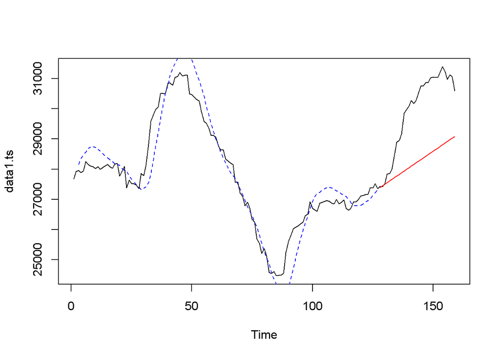

```r
plot(data1.ts)
lines(des.1$fitted[,1], lty=2, col="blue")
lines(ramalandes1$mean, col="red")
```

```r
#Lamda dan gamma optimum
des.opt<- HoltWinters(train.ts, gamma = FALSE)
des.opt
```

```
## Holt-Winters exponential smoothing with trend and without seasonal component.
##
## Call:
## HoltWinters(x = train.ts, gamma = FALSE)
##
## Smoothing parameters:
##  alpha: 0.8218152
##  beta : 0.3469907
##  gamma: FALSE
##
## Coefficients:
##          [,1]
## a 27399.79158
## b    18.62023
```

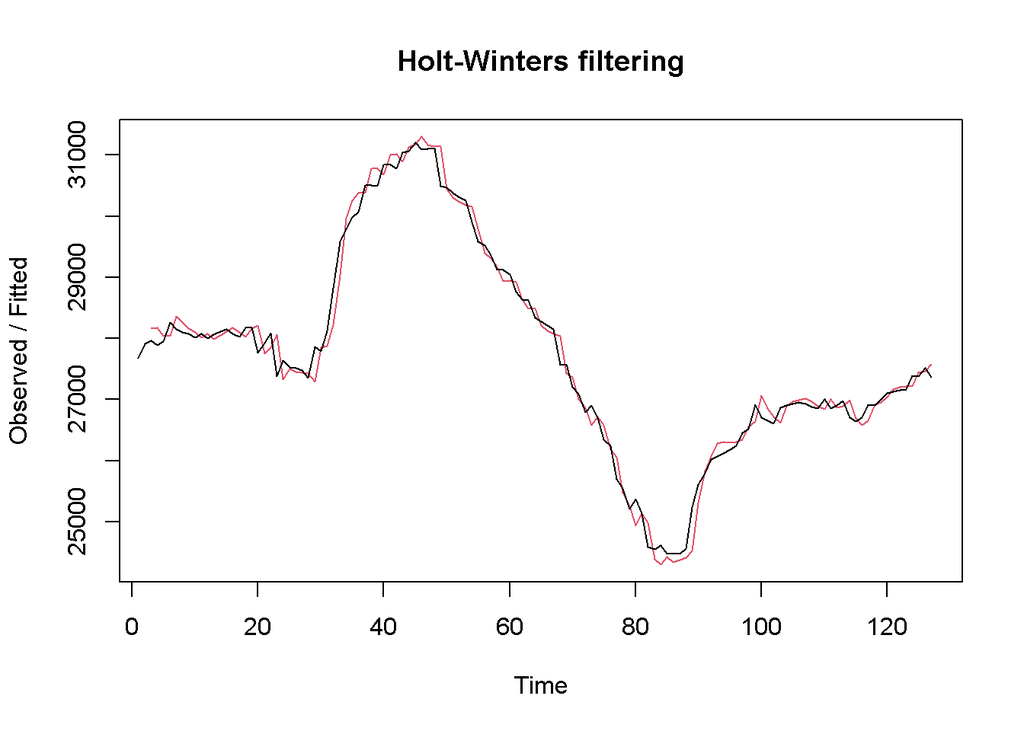

```r
plot(des.opt)
```

```r
#ramalan
ramalandesopt<- forecast(des.opt, h=32)
ramalandesopt
```

```
##     Point Forecast    Lo 80    Hi 80    Lo 95    Hi 95
## 128       27418.41 27136.21 27700.61 26986.82 27850.00
## 129       27437.03 27016.05 27858.01 26793.20 28080.86
## 130       27455.65 26879.84 28031.47 26575.02 28336.29
## 131       27474.27 26728.88 28219.66 26334.29 28614.25
## 132       27492.89 26564.29 28421.50 26072.71 28913.07
## 133       27511.51 26386.96 28636.07 25791.66 29231.37
## 134       27530.13 26197.66 28862.61 25492.29 29567.98
## 135       27548.75 25997.02 29100.49 25175.58 29921.92
## 136       27567.37 25785.60 29349.15 24842.38 30292.36
## 137       27585.99 25563.87 29608.12 24493.42 30678.56
## 138       27604.61 25332.26 29876.97 24129.34 31079.89
## 139       27623.23 25091.13 30155.34 23750.71 31495.76
## 140       27641.85 24840.82 30442.89 23358.05 31925.66
## 141       27660.47 24581.64 30739.31 22951.81 32369.14
```

[output cut: 18 more lines]

#### Akurasi Data Latih

```r
#Akurasi Data Training
ssedes.train1<-des.1$SSE
msedes.train1<-ssedes.train1/length(train.ts)
sisaandes1<-ramalandes1$residuals
head(sisaandes1)
```

```
## Time Series:
## Start = 1
## End = 6
## Frequency = 1
## [1]        NA        NA -200.0000 -462.0000 -523.1200 -301.0912
```

```r
mapedes.train1 <- sum(abs(sisaandes1[3:length(train.ts)]/train.ts[3:length(train.ts)])
                      *100)/length(train.ts)

akurasides.1 <- matrix(c(ssedes.train1,msedes.train1,mapedes.train1))
row.names(akurasides.1)<- c("SSE", "MSE", "MAPE")
colnames(akurasides.1) <- c("Akurasi lamda=0.2 dan gamma=0.2")
akurasides.1
```

```
##      Akurasi lamda=0.2 dan gamma=0.2
## SSE                     4.084564e+07
## MSE                     3.216192e+05
## MAPE                    1.537105e+00
```

```r
ssedes.train2<-des.2$SSE
msedes.train2<-ssedes.train2/length(train.ts)
sisaandes2<-ramalandes2$residuals
head(sisaandes2)
```

```
## Time Series:
## Start = 1
## End = 6
## Frequency = 1
## [1]        NA        NA -200.0000 -354.0000 -221.8800  120.9064
```

```r
mapedes.train2 <- sum(abs(sisaandes2[3:length(train.ts)]/train.ts[3:length(train.ts)])
                      *100)/length(train.ts)

akurasides.2 <- matrix(c(ssedes.train2,msedes.train2,mapedes.train2))
row.names(akurasides.2)<- c("SSE", "MSE", "MAPE")
colnames(akurasides.2) <- c("Akurasi lamda=0.6 dan gamma=0.3")
akurasides.2
```

```
##      Akurasi lamda=0.6 dan gamma=0.3
## SSE                     6.906733e+06
## MSE                     5.438372e+04
## MAPE                    6.076828e-01
```

Berdasarkan nilai SSE, MSE, dan MAPE pada data latih, parameter dengan $\lambda=0,6$ dan $\gamma=0,3$ memiliki hasil yang lebih baik. Namun berdasarkan nilai MAPE-nya, kedua pasangan parameter memiliki akurasi yang sangat baik.

#### Akurasi Data Uji

```r
#Akurasi Data Testing
selisihdes1<-ramalandes1$mean-testing$`Jawa Barat`
selisihdes1
```

```
## Time Series:
## Start = 128
## End = 159
## Frequency = 1
##  [1]   -37.77939    26.81659   -18.58744  -283.99146  -249.39549  -324.79951
##  [7]  -760.20353 -1125.60756 -1121.01158 -1276.41561 -1921.81963 -1977.22366
## [13] -2042.62768 -2168.03171 -2023.43573 -2068.83975 -2274.24378 -2429.64780
## [19] -2395.05183 -2440.45585 -2395.85988 -2491.26390 -2456.66793 -2392.07195
## [25] -2347.47598 -2462.88000 -2578.28402 -2363.68805 -2059.09207 -2154.49610
## [31] -2029.90012 -1505.30415
```

```r
SSEtestingdes1<-sum(selisihdes1^2)
MSEtestingdes1<-SSEtestingdes1/length(testing$`Jawa Barat`)
MAPEtestingdes1<-sum(abs(selisihdes1/testing$`Jawa Barat`)*100)/length(testing$`Jawa Barat`)

selisihdes2<-ramalandes2$mean-testing$`Jawa Barat`
selisihdes2
```

```
## Time Series:
## Start = 128
## End = 159
## Frequency = 1
##  [1]    53.95113   104.86594    45.78074  -233.30446  -212.38965  -301.47485
##  [7]  -750.56004 -1129.64524 -1138.73043 -1307.81563 -1966.90082 -2035.98602
## [13] -2115.07122 -2254.15641 -2123.24161 -2182.32680 -2401.41200 -2570.49719
## [19] -2549.58239 -2608.66758 -2577.75278 -2686.83798 -2665.92317 -2615.00837
## [25] -2584.09356 -2713.17876 -2842.26395 -2641.34915 -2350.43434 -2459.51954
## [31] -2348.60474 -1837.68993
```

```r
SSEtestingdes2<-sum(selisihdes2^2)
MSEtestingdes2<-SSEtestingdes2/length(testing$`Jawa Barat`)
MAPEtestingdes2<-sum(abs(selisihdes2/testing$`Jawa Barat`)*100)/length(testing$`Jawa Barat`)

selisihdesopt<-ramalandesopt$mean-testing$`Jawa Barat`
selisihdesopt
```

```
## Time Series:
## Start = 128
## End = 159
## Frequency = 1
##  [1]   -11.58819    17.03204   -64.34773  -365.72751  -367.10728  -478.48705
##  [7]  -949.86682 -1351.24660 -1382.62637 -1574.00614 -2255.38591 -2346.76569
## [13] -2448.14546 -2609.52523 -2500.90500 -2582.28478 -2823.66455 -3015.04432
## [19] -3016.42409 -3097.80387 -3089.18364 -3220.56341 -3221.94318 -3193.32296
## [25] -3184.70273 -3336.08250 -3487.46227 -3308.84205 -3040.22182 -3171.60159
## [31] -3082.98136 -2594.36114
```

```r
SSEtestingdesopt<-sum(selisihdesopt^2)
MSEtestingdesopt<-SSEtestingdesopt/length(testing$`Jawa Barat`)
MAPEtestingdesopt<-sum(abs(selisihdesopt/testing$`Jawa Barat`)*100)/length(testing$`Jawa Barat`)

akurasitestingdes <-
  matrix(c(SSEtestingdes1,MSEtestingdes1,MAPEtestingdes1,SSEtestingdes2,MSEtestingdes2,
           MAPEtestingdes2,SSEtestingdesopt,MSEtestingdesopt,MAPEtestingdesopt),
         nrow=3,ncol=3)
row.names(akurasitestingdes)<- c("SSE", "MSE", "MAPE")
colnames(akurasitestingdes) <- c("des ske1","des ske2","des opt")
akurasitestingdes
```

```
##          des ske1     des ske2      des opt
## SSE  1.153819e+08 1.349423e+08 2.001113e+08
## MSE  3.605684e+06 4.216947e+06 6.253479e+06
## MAPE 5.544113e+00 5.970076e+00 7.275346e+00
```

#### Perbandingan SES dan DES

```r
MSEfull <-
  matrix(c(MSEtesting1,MSEtesting2,MSEtestingopt,MSEtestingdes1,MSEtestingdes2,
           MSEtestingdesopt),nrow=3,ncol=2)
row.names(MSEfull)<- c("ske 1", "ske 2", "ske opt")
colnames(MSEfull) <- c("ses","des")
MSEfull
```

```
##             ses     des
## ske 1   8846291 3605684
## ske 2   8135122 4216947
## ske opt 8297199 6253479
```

Kedua metode dapat dibandingkan dengan menggunakan ukuran akurasi yang sama, yaitu dengan ukuran akurasi MSE. Hasilnya didapatkan metode DES lebih baik dibandingkan metode SES dilihat dari MSE yang lebih kecil nilainya.